# SCRNAseq quantification comparisons

Joshua Shapiro for CCDL

This notebook contains analysis of some initial benchmarking in runs of Alevin and Kallisto

## Setup

### Load Libraries

```r
library(ggplot2)
library(magrittr)
library(SingleCellExperiment)
library(DropletUtils)
library(tximport)

# set seed
set.seed(2020)
```

### File and directory setup

```r
data_dir <- file.path("data", "quants")
dir.create(data_dir, recursive = TRUE, showWarnings = FALSE)

alevin_data_dir <- file.path(data_dir, "alevin")
dir.create(alevin_data_dir, recursive = TRUE, showWarnings = FALSE)
quant_s3_alevin <- "s3://nextflow-ccdl-results/scpca/alevin-quant"

kallisto_data_dir <- file.path(data_dir, "kallisto")
dir.create(kallisto_data_dir, recursive = TRUE, showWarnings = FALSE)
quant_s3_kallisto <- "s3://nextflow-ccdl-results/scpca/kallisto-quant"

cellranger_data_dir <- file.path(data_dir, "cellranger")
dir.create(cellranger_data_dir, recursive = TRUE, showWarnings = FALSE)
quant_s3_cellranger <- "s3://nextflow-ccdl-results/scpca/cellranger-quant"
```

### Sync S3 files

```r
samples = c("SCPCR000001", "SCPCR000002")
includes = stringr::str_glue("--include \"*/{samples}*\"")

# Alevin files
sync_call <- paste("aws s3 sync", quant_s3_alevin, alevin_data_dir,
                   includes)
system(sync_call, ignore.stdout = TRUE)

# kallisto files
# exclude bus files, which are large
sync_call <- paste("aws s3 sync", quant_s3_kallisto, kallisto_data_dir,
                   includes, '--exclude "*/bus/*"')
system(sync_call, ignore.stdout = TRUE)

# cellranger files
# exclude intermediate and bam files
sync_call <- paste("aws s3 sync", quant_s3_cellranger, cellranger_data_dir,
                   includes,
                   '--exclude "*/SC_RNA_COUNTER_CS/*"',
                   '--exclude "*.bam"', '--exclude "*.bam.bai"')
system(sync_call, ignore.stdout = TRUE)
```

Make a data frame with sample info

```r
quant_dirs <- list.dirs(c(alevin_data_dir, kallisto_data_dir, cellranger_data_dir),
                        full.names = TRUE, recursive = FALSE) %>%
  stringr::str_split("/") %>%
  purrr::map_df( ~ data.frame(tool = .x[3], quant_dir = .x[4], info = .x[4]))

# split ids into components for later processing
quant_info <- quant_dirs %>%
  tidyr::separate(info, sep = "[-]",
                  into = c("sample", "index_type")) %>%
  tidyr::separate(index_type,
                  into = c("index_content", "kmer", "decoy"),
                  extra = "drop") %>%
  # no decoy samples get NA here, convert to text.
  dplyr::mutate(decoy = tidyr::replace_na(decoy, "no"))
```

```
Expected 3 pieces. Missing pieces filled with `NA` in 6 rows [1, 3, 5, 6, 7, 8].
```

### Get Annotations from AnnotationHub

```r
hub = AnnotationHub::AnnotationHub(ask = FALSE)
```

```
snapshotDate(): 2020-04-27
```

```r
# Ensembl v100 Homo sapiens is AH79689
ensdb = hub[["AH79689"]]
```

```
loading from cache
require(“ensembldb”)
```

```r
ensg <- genes(ensdb)
```

Create vectors of mitochondrial genes and coding genes for later.

```r
# create the mitochondrial gene list
mito_genes <- ensg[seqnames(ensg) == 'MT']$gene_id

coding_genes <- ensg[ensg$gene_biotype == "protein_coding"]$gene_id
```

## Process quantification files

### Alevin

Use tximport to make SCEs

```r
alevin_quant_ids <- quant_info %>%
  dplyr::filter(tool == "alevin") %>%
  dplyr::pull(quant_dir)

alevin_sces <- alevin_quant_ids  %>%
  purrr::map(
    ~ tximport(file.path(alevin_data_dir, .x, "alevin", "quants_mat.gz"),
               type = "alevin")) %>%
  purrr::map(
    ~ SingleCellExperiment(list(counts = .x$counts)))
```

```
reading in alevin gene-level counts across cells with fishpond
reading in alevin gene-level counts across cells with fishpond
reading in alevin gene-level counts across cells with fishpond
reading in alevin gene-level counts across cells with fishpond
```

```r
# add names
names(alevin_sces) <- alevin_quant_ids
```

Calculate cell QC statistics for each sample

```r
alevin_sces <- alevin_sces %>%
  purrr::map(
    ~ scater::addPerCellQC(
      .x,
      subsets = list(mito = mito_genes[mito_genes %in% rownames(.x)])
    )
  )
```

Make a data frame of the cell QCs.

```r
alevin_cell_qc <- alevin_sces %>%
  purrr::map_df( ~ as.data.frame(colData(.x)) %>%
                   tibble::rownames_to_column(var = "cell_id"),
                 .id = "quant_id") %>%
  dplyr::left_join(quant_info %>% dplyr::filter(tool == "alevin"),
                   by = c("quant_id" = "quant_dir"))
```

Summarize the total UMIs per cell.

```r
summary(alevin_cell_qc$sum)
```

```
   Min. 1st Qu.  Median    Mean 3rd Qu.    Max.
    157    2778    4458    7417    8880   83703
```

Summarize the number of detected genes per cell.

```r
summary(alevin_cell_qc$detected)
```

```
   Min. 1st Qu.  Median    Mean 3rd Qu.    Max.
     37    1101    1738    2361    3299   10703
```

### Kallisto

Get file basenames (no extension) for import

```r
kallisto_quant_ids <- quant_info %>%
  dplyr::filter(tool == "kallisto") %>%
  dplyr::pull(quant_dir)

base_file <- file.path(kallisto_data_dir, kallisto_quant_ids, "counts", "gene_count")
```

#### Function for reading Kallisto files

Takes a base file name and reads the the `.mtx` file and associated `.barcodes.txt` and `.genes.txt` files.  
Filters cells/barcodes based on the knee plot using `DropletUtils::barcodeRanks()`

```r
read_kallisto_counts <- function(base, cellfilter = c("knee", "none")){
  cellfilter <- match.arg(cellfilter)
  counts <- Matrix::readMM(paste0(base,".mtx"))%>%
    t() %>% # transpose to gene x cell orientation
    as("dgCMatrix") # compress sparse matrix
  dimnames(counts) <- list(readLines(paste0(base,".", "genes.txt")),
                           readLines(paste0(base,".barcodes.txt")))
  if(cellfilter == "knee"){
    # calculate ranks and find knee
    rank_df <- DropletUtils::barcodeRanks(counts)
    cells <- which(rank_df$total >= metadata(rank_df)$knee)
    counts <- counts[, cells]
  }
  return(counts)
}
```

Make a list of kallisto runs as SCEs

```r
kallisto_sces <- base_file %>%
  purrr::map(read_kallisto_counts) %>%
  purrr::map(~ SingleCellExperiment(list(counts = .x)))

# add names
names(kallisto_sces) <- kallisto_quant_ids
```

Calculate cell QC statistics for each sample

```r
kallisto_sces <- kallisto_sces %>%
  purrr::map(
    ~ scater::addPerCellQC(
      .x,
      subsets = list(mito = mito_genes[mito_genes %in% rownames(.x)])
    )
  )
```

Make a table of the SCE cell QCs.

```r
kallisto_cell_qc <- kallisto_sces %>%
  purrr::map_df(~ as.data.frame(colData(.x)) %>%
                  tibble::rownames_to_column(var = "cell_id"),
                .id = "quant_id") %>%
  dplyr::left_join(quant_info %>% dplyr::filter(tool == "kallisto"),
                   by = c("quant_id" = "quant_dir"))
```

```r
summary(kallisto_cell_qc$sum)
```

```
   Min. 1st Qu.  Median    Mean 3rd Qu.    Max.
   5333    6970   10124   13830   16661   96879
```

Summarize the number of detected genes per cell.

```r
summary(kallisto_cell_qc$detected)
```

```
   Min. 1st Qu.  Median    Mean 3rd Qu.    Max.
    290    2674    3675    4055    5085   11465
```

### Cellranger

Use `DropletUtils::read10xCounts` to read cellranger counts as SCEs

```r
cellranger_quant_ids <- quant_info %>%
  dplyr::filter(tool == "cellranger") %>%
  dplyr::pull(quant_dir)


cellranger_sces <- cellranger_quant_ids  %>%
  purrr::map(
    ~ read10xCounts(file.path(cellranger_data_dir, .x,
                              "outs", "filtered_feature_bc_matrix.h5"),
                    col.names = TRUE)
  ) %>%
  purrr::map(
    # get the portion before the "-" which includes the barcode
    function(x) {
      colnames(x) <- stringr::str_extract(colnames(x), "^([^-]+)")
      return(x)
    }
  )

# add names
names(cellranger_sces) <- cellranger_quant_ids
```

Calculate cell QC statistics for each sample

```r
cellranger_sces <- cellranger_sces %>%
  purrr::map(
    ~ scater::addPerCellQC(
      .x,
      subsets = list(mito = mito_genes[mito_genes %in% rownames(.x)])
    )
  )
```

Make a table of the SCE cell QCs.

```r
cellranger_cell_qc <- cellranger_sces %>%
  purrr::map_df(~ as.data.frame(colData(.x)) %>%
                  tibble::rownames_to_column(var = "cell_id"),
                .id = "quant_id") %>%
  dplyr::left_join(quant_info %>% dplyr::filter(tool == "cellranger"),
                   by = c("quant_id" = "quant_dir"))
```

```r
summary(cellranger_cell_qc$sum)
```

```
   Min. 1st Qu.  Median    Mean 3rd Qu.    Max.
    513    2125    3787    6662    7479   91586
```

Summarize the number of detected genes per cell.

```r
summary(cellranger_cell_qc$detected)
```

```
   Min. 1st Qu.  Median    Mean 3rd Qu.    Max.
     24     775    1359    1912    2522   10053
```

## Comparing summary stats across tools

Combine the data frames:

```r
cell_qc <- dplyr::bind_rows(alevin_cell_qc, kallisto_cell_qc, cellranger_cell_qc)
rm(alevin_cell_qc, kallisto_cell_qc, cellranger_cell_qc)
```

Plot distributions of Total UMI counts

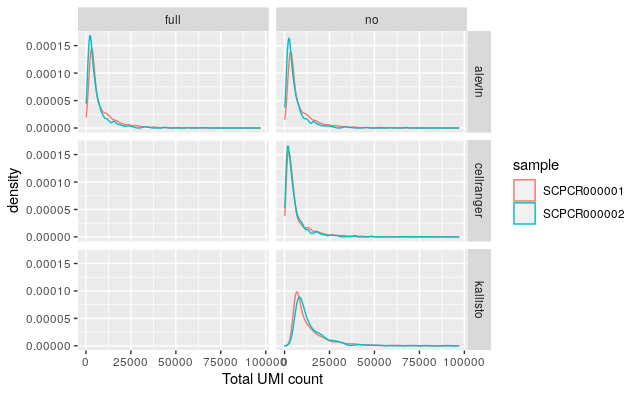

```r
ggplot(cell_qc, aes(x = sum, color = sample)) +
  geom_density() +
  xlab("Total UMI count") +
  facet_grid(tool ~ decoy)
```

Plot distributions of Detected gene counts

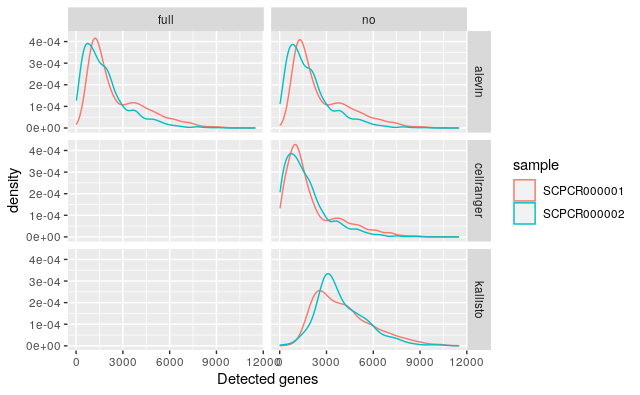

```r
ggplot(cell_qc, aes(x = detected, color = sample)) +
  geom_density() +
  xlab("Detected genes") +
  facet_grid(tool ~ decoy)
```

Kallisto tends to detect more UMIs and more transcripts per cell.

Lets make a little table:

```r
cell_qc %>%
  dplyr::group_by(tool, decoy) %>%
  dplyr::summarize(dplyr::across(
    c(sum, detected, subsets_mito_percent),
    mean))
```

| tool | decoy | sum | detected | subsets_mito_percent |
| --- | --- | --- | --- | --- |
| alevin | full | 7239.478 | 2320.902 | 32.84080 |
| alevin | no | 7595.276 | 2401.678 | 31.23422 |
| cellranger | no | 6662.361 | 1911.987 | 38.13931 |
| kallisto | no | 13830.171 | 4054.949 | 23.13358 |

So, the naive conclusion is that Kallisto is mapping many more UMIs per cell, and capturing more genes (which reduces the mitochondrial percentage).

Is this because we are excluding low count cells in the knee plot?

```r
cell_qc %>%
  dplyr::group_by(tool, decoy) %>%
  dplyr::tally()
```

| tool | decoy | n |
| --- | --- | --- |
| alevin | full | 2848 |
| alevin | no | 2848 |
| cellranger | no | 3822 |
| kallisto | no | 1640 |

Ugh, maybe. Cellranger keeps the most cells, with kallisto the fewest.

Lets filter to the cells that are included with all methods and repeat this. These will be cells where the count of the cell_id is 4 (2 alevin types, + cellranger and kallisto)

```r
cell_counts <- cell_qc %>%
  dplyr::count(cell_id, sample)

common_cells <- cell_counts %>%
  dplyr::filter(n == 4) %>%
  dplyr::pull(cell_id)

cell_qc_common <- cell_qc %>%
  dplyr::filter(
    (cell_id %in% common_cells)
  )
```

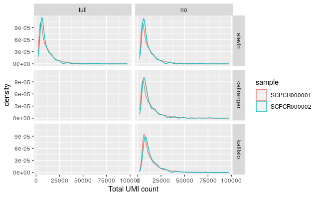

```r
ggplot(cell_qc_common, aes(x = sum, color = sample)) +
  geom_density() +
  xlab("Total UMI count") +
  facet_grid(tool ~ decoy)
```

Plot distributions of Detected gene counts

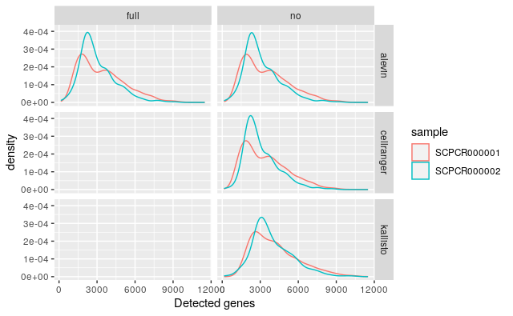

```r
ggplot(cell_qc_common, aes(x = detected, color = sample)) +
  geom_density() +
  xlab("Detected genes") +
  facet_grid(tool ~ decoy)
```

More similar, but still kallisto finds more UMIs and genes per cell.

```r
cell_qc_common %>%
  dplyr::group_by(index_content, tool, decoy) %>%
  dplyr::summarize(dplyr::across(
    c(sum, detected, subsets_mito_percent),
    mean))
```

| index_content | tool | decoy | sum | detected | subsets_mito_percent |
| --- | --- | --- | --- | --- | --- |
| cdna | alevin | full | 10914.93 | 3309.199 | 27.10194 |
| cdna | alevin | no | 11408.39 | 3405.657 | 26.05036 |
| cdna | cellranger | no | 12413.26 | 3322.224 | 26.71937 |
| cdna | kallisto | no | 14021.51 | 4107.463 | 23.06795 |

## Gene-level correlations among methods

Before proceeding, we should reduce our SCEs to our common set of cells for fair comparisons.

```r
#filter and add Feature QC
alevin_sces <- alevin_sces %>%
  purrr::map(~ .x[, colnames(.x) %in% common_cells]) %>%
  purrr::map(scater::addPerFeatureQC)

kallisto_sces <- kallisto_sces %>%
  purrr::map(~ .x[, colnames(.x) %in% common_cells]) %>%
  purrr::map(scater::addPerFeatureQC)

cellranger_sces <- cellranger_sces %>%
  purrr::map(~ .x[, colnames(.x) %in% common_cells]) %>%
  purrr::map(scater::addPerFeatureQC)
```

Combine all feature QC stats into a single data frame.

```r
alevin_feature_qc <- purrr::map_df(
  alevin_sces,
  ~ as.data.frame(rowData(.x)) %>%
    tibble::rownames_to_column(var = "gene_id"),
  .id = "quant_id"
) %>%
  dplyr::left_join(quant_info %>% dplyr::filter(tool == "alevin"),
                   by = c("quant_id" = "quant_dir"))

kallisto_feature_qc <- purrr::map_df(
  kallisto_sces,
  ~ as.data.frame(rowData(.x)) %>%
    tibble::rownames_to_column(var = "gene_id"),
  .id = "quant_id"
) %>%
  dplyr::left_join(quant_info %>% dplyr::filter(tool == "kallisto"),
                   by = c("quant_id" = "quant_dir"))

cellranger_feature_qc <- purrr::map_df(
  cellranger_sces,
  ~ as.data.frame(rowData(.x)) %>%
    tibble::rownames_to_column(var = "gene_id"),
  .id = "quant_id"
) %>%
  dplyr::left_join(quant_info %>% dplyr::filter(tool == "cellranger"),
                   by = c("quant_id" = "quant_dir"))

feature_qc <- dplyr::bind_rows(alevin_feature_qc,
                               kallisto_feature_qc,
                               cellranger_feature_qc)
rm(alevin_feature_qc, kallisto_feature_qc, cellranger_feature_qc)
```

Get features that were found in at least 5% of cells in at least one sample.

```r
detected_features <- feature_qc %>%
  dplyr::filter(detected >= 5.0) %>%
  dplyr::pull(gene_id) %>%
  unique()
# How many?
length(detected_features)
```

```
[1] 15995
```

```r
# spread table for comparisons (no decoy samples)
feature_compare <- feature_qc %>%
  dplyr::filter(gene_id %in% detected_features,
                decoy == "no") %>%
  tidyr::pivot_wider(id_cols = c(gene_id, sample),
                     names_from = tool,
                     values_from = mean) %>%
  # add in the decoys
  dplyr::inner_join(feature_qc %>%
                      dplyr::filter(decoy == "full") %>%
                      dplyr::select(gene_id,
                                    sample,
                                    alevin_decoy = mean ),
                    by = c("gene_id", "sample")) %>%
  tidyr::drop_na()
```

What do the correlations look like? We’ll calculate Spearman correlations first, even though those may overemphasize some of the small differences, because they also won’t be overwhelmed by the highly expressed genes.

```r
feature_compare %>%
  dplyr::group_by(sample) %>%
  dplyr::summarize(
    cr_al_cor = cor(cellranger, alevin, method = "spearman"),
    cr_al_decoy_cor = cor(cellranger, alevin_decoy, method = "spearman"),
    cr_ka_cor = cor(cellranger, kallisto, method = "spearman"),
    al_ka_cor = cor(alevin, kallisto, method = "spearman")
  )
```

| sample | cr_al_cor | cr_al_decoy_cor | cr_ka_cor | al_ka_cor |
| --- | --- | --- | --- | --- |
| SCPCR000001 | 0.9505482 | 0.9633403 | 0.8368597 | 0.8358733 |
| SCPCR000002 | 0.9473650 | 0.9639471 | 0.8103755 | 0.8132680 |

Overall, these seem like decent correlations, but the best correlations are between Cellranger and Alevin, with a slightly better correlation when we use the full decoy index. I was somewhat surprised by the more divergent showing for Kallisto, but it does seem like it’s speed does come with a tradeoff, at least as far as comparing to the “standard” of Cellranger.

Below are plots of the relationships among the callers.

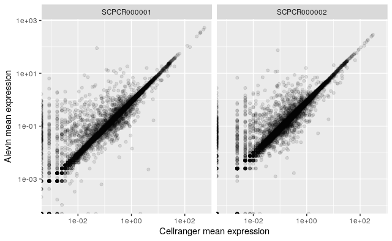

```r
ggplot(feature_compare, aes(x = cellranger, y = alevin)) +
  geom_point(alpha = 0.1) +
  facet_wrap(~ sample) +
  scale_x_log10() +
  scale_y_log10() +
  labs(x = "Cellranger mean expression", y = "Alevin mean expression")
```

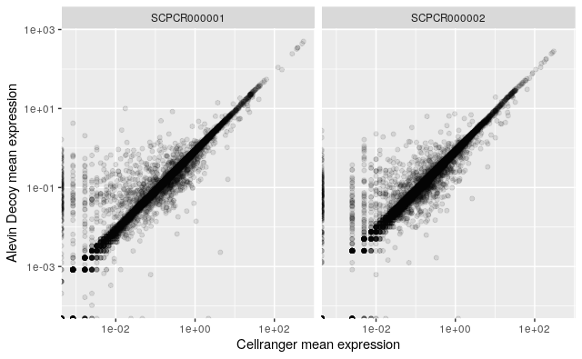

```r
ggplot(feature_compare, aes(x = cellranger, y = alevin_decoy)) +
  geom_point(alpha = 0.1) +
  facet_wrap(~ sample) +
  scale_x_log10() +
  scale_y_log10() +
  labs(x = "Cellranger mean expression", y = "Alevin Decoy mean expression")
```

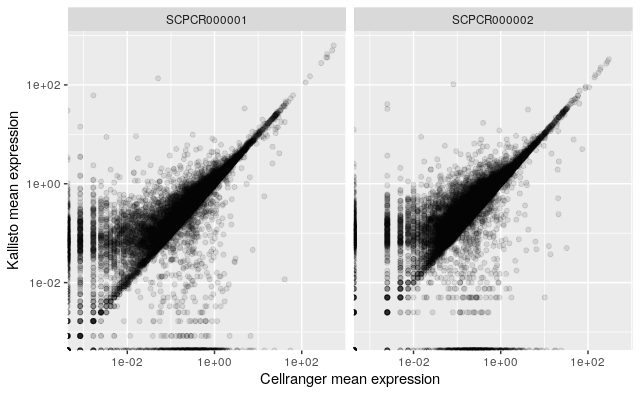

```r
ggplot(feature_compare, aes(x = cellranger, y = kallisto)) +
  geom_point(alpha = 0.1) +
  facet_wrap(~ sample) +
  scale_x_log10() +
  scale_y_log10() +
  labs(x = "Cellranger mean expression", y = "Kallisto mean expression")
```

What seems apparent from these plots is that while all quantification methods are generally well correlated, especially for highly expressed genes, there is a class of genes for which the pseudomapping aligners are more likely to call a higher level of expression than Cellranger. This is most pronouced for Kallisto, perhaps because it does not perform a selective alignment step like Alevin does. The decoy-aware mapping that Alevin can do improves correlations slightly. It may not be be a major benefit, but the runtime cost did not seem too high. Memory use was higher, but for the machines on AWS, this was not a concern, as there is plenty of available memory per CPU for all machines.

In the future, it may be interesting to explore which genes get the most “benefit” from the decoy index, as well as which genes are most divergent between Alevin and Kallisto. For now though, I think that is beyond the scope of this notebook.